# Evaluación curso R

MIGUEL ANGEL BELTRAN VICIANO

## Entrega

- Recuerda completar tu **nombre en el apartado author**.
- Además del código, no olvides completar las respuestas a las preguntas indicadas en negrita.
- Si tienes dudas/dificultades, **puedes contactar con los profesores**.
- Deadline: **viernes 10 de junio, 23:59**.
- Puedes realizar la entrega en el mail: **constantino.garciama@ceu.es**.
- La entrega consistirá en este fichero rellenado y el fichero que se genera al hacer `Knit` (un fichero `Rmd` y un fichero `html`).

## Apuestas de adolescentes en UK

El conjunto de datos `teengamb.csv` contiene datos sobre las tasas de juego entre los adolescentes en Gran Bretaña, su género y estatus socioeconómico. Una pregunta que nos puede interesar es cómo se relacionan el género y los ingresos con cuánto juega una persona (céntrate solo en las variables `income`, `sex` y `gamble`)… Sigue los siguientes pasos para crear un ANCOVA…

### 1) Carga y visualiza los datos…

…para valorar si el modelo debe incluir interacciones. Escribe claramente tus conclusiones

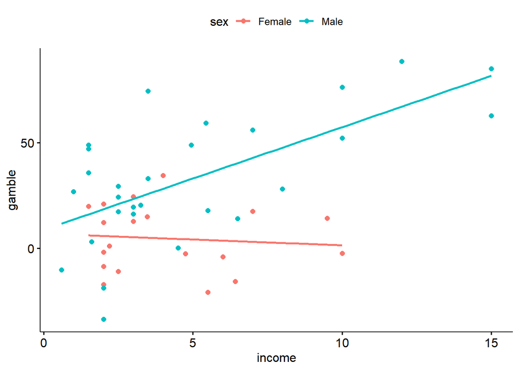

```r
library("ggpubr")
library("effectsize")

datos<- read.csv("C:\\Users\\mabel\\OneDrive\\Escritorio\\curso r\\teengamb.csv")
Datos<-datos [c("income","sex","gamble")]
ggscatter(Datos, x="income", y="gamble", color="sex",add="reg.line")
```

Observamos diferentes pendientes en las rectas de hombre y mujeres,en los hombres positiva ( mas ingresos, mas juego) y en mujeres negativa (mas ingresos igual o menos juego). Por lo tanto, incorporar interacción sería adecuado, pero debemos tener en cuenta que violamos una hipótesis del modelo ANCOVA.

**Conclusiones sobre la necesidad de interacción**:

### 2) Crea el modelo…

… y obtén:

- los intervalos de confianza para los coeficientes y su significación.
- Obtén los tamaños de los efectos.

```r
modelo<-lm(gamble~sex+income, data=Datos)
summary (modelo)
```

```
##
## Call:
## lm(formula = gamble ~ sex + income, data = Datos)
##
## Residuals:
##     Min      1Q  Median      3Q     Max
## -55.440 -14.700   0.594  15.623  46.931
##
## Coefficients:
##             Estimate Std. Error t value Pr(>|t|)
## (Intercept) -10.7926     6.3879  -1.690 0.098191 .
## sexMale      25.2190     6.6463   3.794 0.000449 ***
## income        3.7088     0.9284   3.995 0.000243 ***
## ---
## Signif. codes:  0 '***' 0.001 '**' 0.01 '*' 0.05 '.' 0.1 ' ' 1
##
## Residual standard error: 22.21 on 44 degrees of freedom
## Multiple R-squared:  0.4382, Adjusted R-squared:  0.4126
## F-statistic: 17.16 on 2 and 44 DF,  p-value: 3.1e-06
```

```r
confint(modelo)
```

```
##                  2.5 %    97.5 %
## (Intercept) -23.666503  2.081342
## sexMale      11.824182 38.613857
## income        1.837785  5.579747
```

```r
modelo2<-lm(gamble~sex+income+sex:income, data=Datos)
summary(modelo2)
```

```
##
## Call:
## lm(formula = gamble ~ sex + income + sex:income, data = Datos)
##
## Residuals:
##     Min      1Q  Median      3Q     Max
## -52.025 -15.479  -3.559  14.022  48.625
##
## Coefficients:
##                Estimate Std. Error t value Pr(>|t|)
## (Intercept)      6.8743     9.2446   0.744   0.4612
## sexMale          1.8427    11.1946   0.165   0.8700
## income          -0.5489     1.9024  -0.289   0.7743
## sexMale:income   5.4050     2.1435   2.522   0.0155 *
## ---
## Signif. codes:  0 '***' 0.001 '**' 0.01 '*' 0.05 '.' 0.1 ' ' 1
##
## Residual standard error: 20.97 on 43 degrees of freedom
## Multiple R-squared:  0.5105, Adjusted R-squared:  0.4764
## F-statistic: 14.95 on 3 and 43 DF,  p-value: 8.279e-07
```

```r
confint(modelo2)
```

```
##                     2.5 %    97.5 %
## (Intercept)    -11.769152 25.517839
## sexMale        -20.733425 24.418773
## income          -4.385455  3.287728
## sexMale:income   1.082260  9.727751
```

```r
Resultadosanova<-anova(modelo)
print(Resultadosanova)
```

```
## Analysis of Variance Table
##
## Response: gamble
##           Df  Sum Sq Mean Sq F value    Pr(>F)
## sex        1  9055.6  9055.6  18.355 9.811e-05 ***
## income     1  7873.7  7873.7  15.960 0.0002427 ***
## Residuals 44 21707.2   493.3
## ---
## Signif. codes:  0 '***' 0.001 '**' 0.01 '*' 0.05 '.' 0.1 ' ' 1
```

```r
eta_squared(Resultadosanova)
```

```
## # Effect Size for ANOVA (Type I)
##
## Parameter | Eta2 (partial) |       95% CI
## -----------------------------------------
## sex       |           0.29 | [0.12, 1.00]
## income    |           0.27 | [0.10, 1.00]
##
## - One-sided CIs: upper bound fixed at [1.00].
```

```r
Resultadosanova2<-anova(modelo2)
print(Resultadosanova2)
```

```
## Analysis of Variance Table
##
## Response: gamble
##            Df  Sum Sq Mean Sq F value    Pr(>F)
## sex         1  9055.6  9055.6 20.5908 4.527e-05 ***
## income      1  7873.7  7873.7 17.9035 0.0001195 ***
## sex:income  1  2796.4  2796.4  6.3585 0.0154683 *
## Residuals  43 18910.9   439.8
## ---
## Signif. codes:  0 '***' 0.001 '**' 0.01 '*' 0.05 '.' 0.1 ' ' 1
```

```r
eta_squared(Resultadosanova2)
```

```
## # Effect Size for ANOVA (Type I)
##
## Parameter  | Eta2 (partial) |       95% CI
## ------------------------------------------
## sex        |           0.32 | [0.14, 1.00]
## income     |           0.29 | [0.12, 1.00]
## sex:income |           0.13 | [0.01, 1.00]
##
## - One-sided CIs: upper bound fixed at [1.00].
```

### 3) Interpreta los coeficientes y escribe tus conclusiones.

**Conclusiones sobre las variables de interés**:

En el caso del modelo con inteeacción, los coeficientes ser hombre y mayores ingresos, no son significativos, siendo significativa la interacción entre ambos. Sin embargo, observamos que el ajuste del modelo, es superior (51,05% de R2).

En los dos modelos se observa que los dos factores (sexo, ingresos) tienen una relación significativa con la cantidad que juegan los adolescentes. Observamos que la interacción sex.income es menos significativa, pero podría considerarse.

### 4) Crea un gráfico con las predicciones de tu modelo…

…y compáralas con los datos reales.

```
## No summary function supplied, defaulting to `mean_se()`
## No summary function supplied, defaulting to `mean_se()`
```

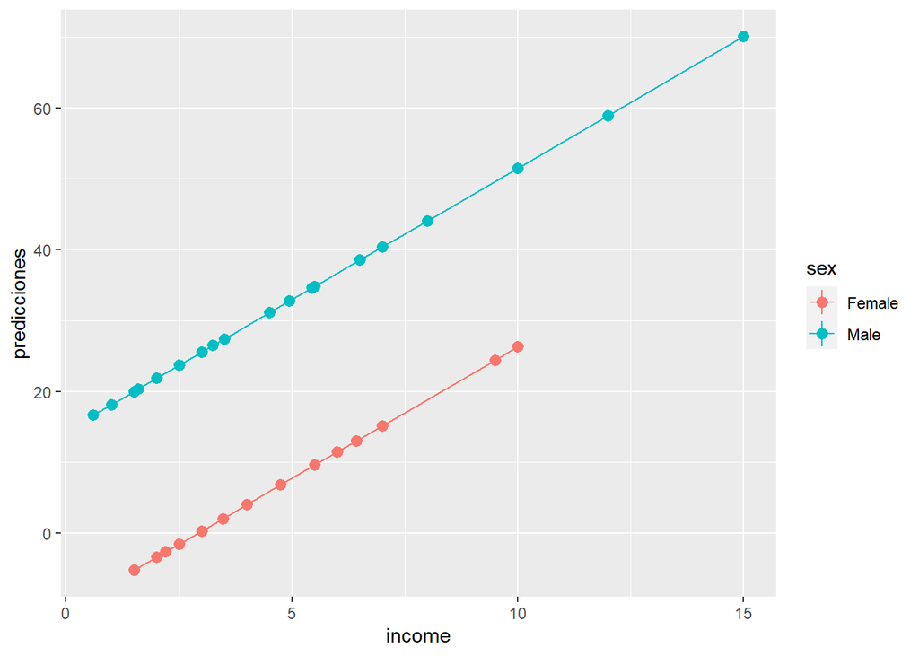

```r
predicciones<-predict(modelo)
ggplot(Datos, aes(x=income, y=predicciones,col=sex))+stat_summary()+stat_summary(geom="line", aes(group=sex))
```

```
## No summary function supplied, defaulting to `mean_se()`
## No summary function supplied, defaulting to `mean_se()`
```

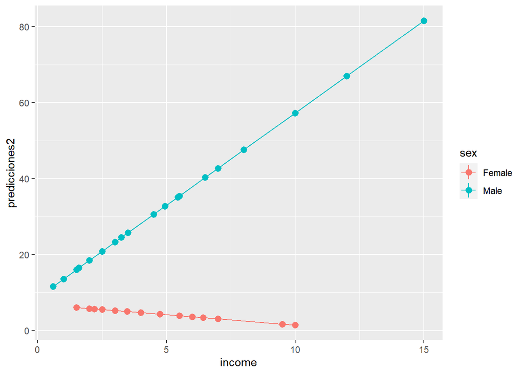

```r
predicciones2<-predict(modelo2)
ggplot(Datos, aes(x=income, y=predicciones2,col=sex))+stat_summary()+stat_summary(geom="line", aes(group=sex))
```

**¿Es bueno el ajuste?:**

Segun el modelo sin interaccion, tenemos dos rectas diferenciadas según sexos, mas elevada en hombres mas elevada que en mujeres. Si comparamos este gráfico con el diagrama de dispersión de los datos inical, comprobaremos que: 1) Existe una gran variabilidad en los datos con respecto a las rectas obtenidas. 2) En el modelo de mujeres la pendiente es positiva (mas ingresos mas juego) y en la realidad, la pendiente seria constante o negativa (a más ingresos igual o menor juego).

Si utilizamos el modelo con la interacción, el modelo se ajustaría más a la realidad de los datos. Especialmente en la recta de mujeres. Sin embargo, este modelo viola la asunción de que las pendientes de las rectas son iguales (homogeneidad de pendientes) que no garantizarian la fiabilidad del analisis ANCOVA.

### 5) Valora si las asunciones del modelo se cumplen

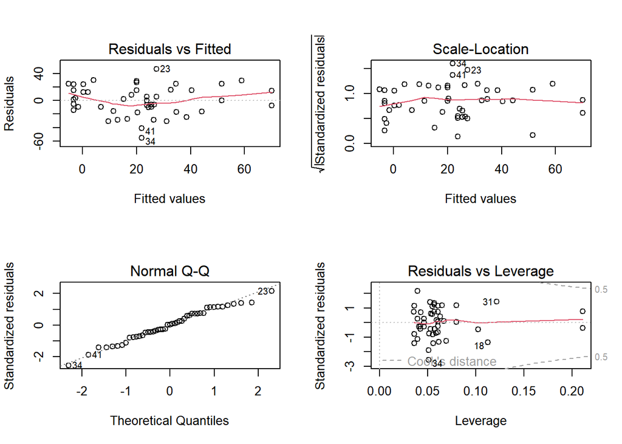

```r
par(mfcol=c(2,2))
plot (modelo)
```

**¿Es el modelo correcto?:**

Los residuos siguen una distribución normal. Los residuos presentan una varianza homogenea (homocedasticidad).